# Are Highly Educated People More Likely to Read Newspaper Every Day Than Less Educated in 2012?

K. Tao

April 19, 2015

### I Introduction

A newspaper, as an important information source, used to be an integral part of many people’s daily life. Over the past decade, internet, mobile technology and social media have been transforming the way how people get the news [1]. Naturally, the demographic profile of newspaper readers is undergoing major changes. In this project, I am interested in examining the most recent pattern of newspaper readership across various education levels by using the 2012 General Social Survey. Specifically, I would like to address the following research question: are highly educated people (persons with a bachelor’s degree or higher) more likely to read newspaper every day than less edcuated (junior college or lower) in 2012? The primary goal of this study is to apply rigorous statistical inference to investigate the association between educational attainment and the likelihood of frequently following traditional news sources such as newspapers.

The rest of this report is organized as follows: Section II gives an overview of the dataset to be analyzed, namely, source, collection, cases, variables selected, type of study, as well as scope of inference. Section III performs an exploratory data analysis to gain an insight of the data with the summary statistics and its visualization. Section IV conducts both hypothesis test and confidence interval to determine the statistical significance of the initial findings from Section III. My conclusion and possible directions of future work are presented in Section V.

### II Data

The dataset used in this study comes from the General Social Survey Cumulative File, 1972-2012 Coursera Extract (hereafter referred to as the “Coursera Extract”) [2].

The General Social Surveys (GSS) aims at collecting data on demographic characteristics and attitudes of US residents for sociological studies [3][2]. It has been conducted via questionnaires since 1972. There are a total of 57,061 interviews, completed either by computer-assisted personal or face-to-face or telephone, and 1974 of them were carried out in 2012. Starting in 2006, each survey was an independently drawn sample of noninstitutionalized, English and Spanish speaking US residents 18 years of age or older. Full probability sampling was employed in surveys from 1977 to 2012 [3].

Compared with the full GSS dataset, the Coursera Extract is especially adapted for the Data Analysis and Statistical Inference course taught by Dr. Mine Çetinkaya-Rundel at Duke University. It provides a sample of selected indicators in the GSS, and is easier to use because all missing values have been recoded to NA and factor variables have been created when appropriate [2]. For more details about the extracted and the original GSS cumulative file , please check [2] and [3] in the reference list.

In terms of this Coursera Extract, a case is a unit of observation, or an individual. After loading the GSS dataset into R, each row in the `gss` data.frame is a case. There are 57061 cases and 114 variables.

The two variables which I picked up are `news` and `degree`. They both are ordinal categorical variables.

Variable `news` refers to the answers of how often a Respondent reads newspaper and it has five levels: 1) Everyday, 2) Few Times A Week, 3) Once A Week, 4) Less Than Once Wk, and 5) Never.

For the convenience of this research study, I will further group them into two levels:  
**Everyday**  
**Not Everyday**: including Few Times A Week, Once A Week, Less Than Once Wk and Never

Variable `degree` refers to a Respondent’s highest degree and it also has five levels: 1) Lt High School, 2) High School, 3) Junior College, 4) Bachelor, and 5) Graduate.

For a similar reason, I will further classify them into two levels:  
**Less Educated**: including Lt High School, High School and Junior College  
**Highly Educated**: consisting of Bachelor and Graduate

This is an observational study. Both variables in my analysis, that is, `news` and `degree` are obtained via the GSS 2012 which employed a full probability sampling. Probability sampling is a random sampling technique wherein each case in the population has an equal chance of being selected. Moreover, there was no direct interference involved with how the data arose regarding the information collection of these two variables [3]. In addition, after I extracted them from the GSS 2012 Coursera Extract, I merely observe the data, analyze them by using tabulation and visualization, as well as conduct statistical inference to provide evidence of a naturally occurring association between them. There was no assignment of treatments to cases during the survey and during my study. Therefore, it is not an experiment.

The population of interest in my study is all residents of the United States in 2012. However, the findings from this analysis cannot be generalized to that population. The reason is that the GSS 2012 was conducted among noninstitutionalized, English and Spanish speaking persons 18 years of age or older, living in the United States [3]. In other words, institutionalized, non-English and non-Spanish speaking US residents younger than 18 years old were not included in the survey. Consequently, we can only expect the findings to be generalized to a subsection of the aforementioned population.

Now a further question is: are the findings really true regarding the target population covered by the survey? Theoretically, yes, but practically, there may be still some uncertainty. First all, I noticed that only 1299 respondents who answered both questions related to `news` and `degree` although there are 1974 cases in the 2012 dataset. The response rate was about 65.8%. Hence, the survey may only reach a certain group within population. Secondly, the survey question related to `news` did not clarify whether both print and online readers were taken into consideration. In a Digital Age, it may confuse respondents and hence bias the results.

It is worth mentioning that these data cannot be used to establish causal links between the variables of interest. The information contained in `news` and `degree` was obtained via the General Social Survey 2012. There were no treatments assigned to cases during the data collection of these two variables, and there was no direct interference involved with how the data arose. As I said earlier, this is an observational study, not a randomized experiment. Making causal connection based on an observational study is not recommended, and causation can only be inferred from a randomized experiment [4].

### III Exploratory Data Analysis

#### 3.1 Summary Statistics

Let’s load the GSS dataset into R, create a subset of 2012, and then extract `news` and `degree` to produce a new data frame called `newsDeg12` (See Appendix for its first 56 rows).

```r
load(url("http://bit.ly/dasi_gss_data"))
gss2012 = subset(gss, gss$year == 2012)
degree <- gss2012$degree
news <- gss2012$news
newsDeg12 <- data.frame(news, degree)
```

Next, remove all `NA` and tabulate `news` versus `degree`.

```r
newsDeg12 <- newsDeg12[complete.cases(newsDeg12), ]
tbNewsDeg <- table(newsDeg12)
Total <- as.integer(rowSums(tbNewsDeg))
tbNewsDegRowTot <- cbind(tbNewsDeg, Total)
Total <- as.integer(colSums(tbNewsDegRowTot))
tbNewsDegTot <- rbind(tbNewsDegRowTot, Total)
```

The contingency table is as follows:

**Table 1**: A contingency table for `news` and `degree`.

|  | Lt High School | High School | Junior College | Bachelor | Graduate | Total |
| --- | --- | --- | --- | --- | --- | --- |
| Everyday | 25 | 161 | 22 | **75** | 69 | **352** |
| Few Times A Week | 26 | 121 | 18 | 39 | 26 | 230 |
| Once A Week | 28 | 112 | 15 | 26 | 14 | 195 |
| Less Than Once Wk | 37 | 117 | 15 | 40 | 7 | 216 |
| Never | 62 | 156 | 24 | 44 | 20 | 306 |
| Total | 178 | **667** | 94 | 224 | 136 | **1299** |

Each value in **Table 1** represents the number of people for a particular combination of `news` and `degree` outcomes. Row and column totals are also included. For example, the value 75 means 75 bachelor’s degree holders read newspaper every day, and 352 indicates the total number of everyday newspaper readers, whereas 667 denotes the total high school diploma holders.

Respectively group `news` and `degree` in **Table 1** into two levels, that is, **Everyday** versus **Not Everyday** for `news`, whereas **Less Educated** versus **Highly Educated** for `degree`. Then, summarize variable `news` and `degree` again with respect to the *newly coded* levels. The output is shown in **Table 2a**. To make this aggregation process more understandable, relevant parts of **Table 1** and **Table 2a** are highlighted with the same color. For instance, the value 208 in **Table 2a**, which stands for the the number of less educated people who read newspaper every day, is equal to the sum of 25, 161 and 22 in **Table 1**, and hence they are all in *Frosted Mint* color.

Finally, replace pertinent counts in **Table 2a** with percentages and list them in **Table 2b**. Again, corresponding parts are in the same color. For example, there are a total of 360 highly educated people among whom 144 persons are everyday readers, accounting for 40.00%, while the rest 216, who read newspaper less frequently, accounts for the other 60.00%.

**Table 2a**: A contingency table regarding newly coded levels.

|  | Less Educated | Highly Educated | Total |
| --- | --- | --- | --- |
| Everyday | 208 | 144 | 352 |
| Not Everyday | 731 | 216 | 947 |
| Total | 939 | 360 | 1299 |

**Table 2b**: A contingency table of percentages.

|  | Less Educated | Highly Educated |
| --- | --- | --- |
| Everyday | 22.15% | 40.00% |
| Not Everyday | 77.85% | 60.00% |
| Total | 100.00% | 100.00% |

#### 3.2 Visualization

A visualization of the summary statistics is shown in **Figure 1**. The green bars respectively represent the percentages of the less educated and highly educated people who read newspaper every day, while the yellows bars indicate the percentages of people who do not read newspaper so often in the above two groups. The sum of the heights of each green-yellow pair is equal to 100%.

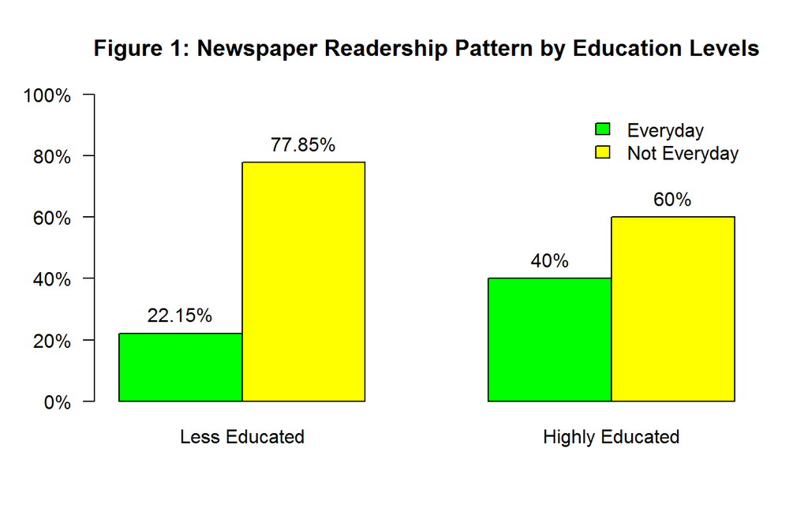

```r
lessEdu <- c(22.15, 77.85)
highEdu <- c(40, 60)
eryNotEryEduScaled <- data.frame(lessEdu, highEdu)
colnames(eryNotEryEduScaled) <- c("Less Educated", "Highly Educated")
rownames(eryNotEryEduScaled) <- c("Everyday", "Not Everyday")
eryNotEryEduScaled <- as.matrix(eryNotEryEduScaled)
bplot <- barplot(eryNotEryEduScaled, beside = TRUE, legend = TRUE, args.legend = list(bty = "n"), col = c("green", "yellow"),
                 main = "Figure 1: Newspaper Readership Pattern by Education Levels", ylim = c(0, 100), yaxt='n')
yTick = seq(0, 100, by = 20)
yLab = c("0%", "20%", "40%", "60%", "80%", "100%")
axis(side = 2, at = yTick, labels = yLab, las = 2)
pct <- eryNotEryEduScaled
pct <- format(round(pct, 2), nsmall = 2)
pct <- as.numeric(as.character(pct))
text(bplot, y = pct, label = paste(pct, "%", sep = ""), pos = 3, col = "black")
```

#### 3.3 Discussion

As we can see from **Table 2b** and **Figure 1**, in terms of everyday newspaper reading, the percentage difference between the highly educated and less educated people is 40.00% - 22.15% = 17.85%, which suggests the answer to my research question is perhaps Yes. However, to make sure the observed difference is not simply due to chance, we will have to resort to statistical inference methodologies as explained in the next section.

### IV Inference

There are two classical ways to determine whether the difference between two proportions is statistically significant: hypothesis test and confidence interval. Let’s go though these two methods one by one.

#### 4.1 Hypothesis Test for Comparing Two Proportions

According to my research question, a **one-sided** hypothesis test is appropriate. So, the two competing hypotheses are:

Null hypothesis $H_0$: Highly educated and less educated people are equally likely to read newspaper every day.  
Alternative hypothesis $H_A$: Compared to the less educated, highly educated people are more likely to read newspaper every day.

Let $p_{high}$ and $p_{less}$ respectively denote the population proportion of everyday readers among the highly educated and less educated people, then the above hypotheses can be formulated as:

$H_0$ = $p_{high}$ - $p_{less}$ = 0  
$H_A$ = $p_{high}$ - $p_{less}$ > 0

Next, check whether conditions for such a hypothesis test are met or not. First, examine the **Independence** of the sample. As we see from Section II, the GSS 2012 was an independently drawn sample with full probability sampling employed, moreover, 360 and 939 are definitely less than 10% of the respective target population. So, *within groups*, sampled less educated people are independent of each other, and the same thing is true of the sampled highly educated people; *between groups*, no reason to expect these two sampled groups to be dependent. Secondly, inspect the condition of **Sample size/skew**. From **Table 2a**, the estimated **pooled proportion** of everyday readers is: $\hat p$$_{pool}$ = 352 / 1299 = 0.27. Thus, the *success-failure condition* is:

For highly educated: 360 * 0.27 = 97.2 > 10 and 360 * (1 - 0.27) = 262.8 > 10  
For less educated: 939 * 0.27 = 253.5 > 10 and 939 * (1 - 0.27) = 685.5 > 10

Both **independence** and **success-failure** conditions are met. We can assume that the sampling distribution of the proportion difference is nearly normal. Therefore, we can conduct the hypothesis test theoretically.

The stand error *SE* = sqrt(0.27 * 0.73 / 360 + 0.27 * 0.73 / 939) = 0.0275. Let $\hat p$$_{high}$ and $\hat p$$_{less}$ respectively be the sample proportion of everyday readers in the highly educated and less educated groups, then:

($\hat p$$_{high}$ - $\hat p$$_{less}$) ~ *N* (0, 0.0275)
*point estimate* = $\hat p$$_{high}$ - $\hat p$$_{less}$ = 0.40 - 0.2215 = 0.1785
*Z* = (0.1785 - 0) / 0.0275 = 6.49

For the **one-sided** hypothesis test in this study, the *p-value* is the conditional probability of observing a 17.85% difference or higher with a random sample of 360 highly educated and 939 less educated if the null hypothesis is true. So, *p-value* = P(*Z* > 6.49). Using the **pnorm()** function in R, we have:

```r
pnorm(6.49, 0, 1, lower.tail = FALSE)
```

```
[1] 4.291819e-11
```

That is, *p-value* = 4.291819e-11, which is much less than the most commonly used 5% significance level, so the null hypothesis is rejected. The data do provide a convincing evidence that highly educated people are more likely to read newspaper every day.

#### 4.2 Evaluate the Difference with a 95% Confidence Interval

Besides the *p-value*, confidence interval can also be used to evaluate whether the difference between two proportions is significant or not. The mock null and alternative hypotheses, as well as the procedure to check the **independence** condition are the same as stated in Section 4.1, and there is no need to repeat here. Let’s examine the *success-failure condition*. From **Table 2a**, we see:

For highly educated: 144 *successes* and 216 *failures*, both are greater than 10.  
For less educated: 208 *successes* and 731 *failures*, both are larger than 10.

Again, the condition is met. We can assume that the sampling distribution of the difference between two proportions is nearly normal and calculate the 95% confidence interval as follows:

*SE* = sqrt(0.4 * 0.6 / 360 + 0.2215 * 0.7785 / 939) = 0.0292
*95% CI* = ($\hat p$$_{high}$ - $\hat p$$_{less}$) ± *z*<sup>$*$</sup>*SE* = (0.4 - 0.2215) ± 1.96 * 0.0292 = (0.121268, 0.235732)

namely, we are 95% confident that the population percentage of highly educated daily reader is 12.13% to 23.57% higher than less educated. Since the null value 0 is outside this interval, we reject $H_0$ in favor of the **one-tailed** $H_A$ at the 2.5% significance level.

The results from the hypothesis test and the confidence interval agree very well with each other.

### V Conclusion:

In this study, the relationship between newspaper reading frequency and education level is investigated with the GSS 2012 dataset. Both the hypothesis test and the confidence interval provide strong evidence that the percentage of highly educated people who read newspaper every day is significantly higher than those with less education.

The original sample size of the GSS 2012 is 1974. Regarding the selected variables `news` and `degree`, the response rate was about 65.8%, not perfect, but acceptable [4]. In other words, the actual cases available for this analysis is 1299 among which 360 individuals are highly educated, and the rest 939 are less educated. 40.00% of the sampled well-educated people are daily newspaper readers, which is 17.85% greater than the proportion of the sampled less educated. The hypothesis test shows if the likelihood of being a daily reader between two groups is equal, the probability of observing a 17.85% difference or higher is only 4.291819e-11. Hence the $H_0$ is rejected. Meanwhile, the 95% confidence interval estimated from the sample is about (12.13%, 23.57%). The null value is outside this interval, which strongly favors the alternative hypothesis. Based on the outcomes of both inference methods, the answer to my research question is YES.

As mentioned before, due to the potential non-response bias, results obtained from this sutdy might be skewed. Since the GSS 2012 adopted the non-respondent, sub-sampling design [3], one possible future research direction would be to investigate the effect of weighting adjustments for nonresponse correction. In addition, with other public data sources, it is also interesting to find out the preferred newspapers and the preferred way to access them for people from different educational backgrounds.

### References:

[1] “How Americans get their news.” 17 Mar 2014 http://www.americanpressinstitute.org/publications/reports/survey-research/how-americans-get-news/

[2] General Social Survey Cumulative File, 1972-2012 Coursera Extract  
GSS dataset URL: http://bit.ly/dasi_gss_data  
Codebook URL: https://d396qusza40orc.cloudfront.net/statistics%2Fproject%2Fgss1.html

[3] Smith, Tom W., Michael Hout, and Peter V. Marsden. General Social Survey, 1972-2012 [Cumulative File]. ICPSR34802-v1. Storrs, CT: Roper Center for Public Opinion Research, University of Connecticut /Ann Arbor, MI: Inter-university Consortium for Political and Social Research [distributors], 2013-09-11.  
Persistent URL: http://doi.org/10.3886/ICPSR34802.v1  
Codebook URL: http://www.icpsr.umich.edu/cgi-bin/file?comp=none&study=34802&ds=1&file_id=1136502&path=ICPSR

[4] Diez, D.M., Barr, C.D., Çetinkaya-Rundel, M. (July 2014). *OpenIntro Statistics*. Retrieved from https://www.openintro.org/stat/textbook.php

### Appendix:

```
                news         degree
1        Once A Week       Bachelor
2               <NA>    High School
3               <NA>    High School
4   Few Times A Week    High School
5   Few Times A Week       Bachelor
6           Everyday       Bachelor
7              Never Junior College
8               <NA> Lt High School
9        Once A Week Lt High School
10              <NA>       Bachelor
11          Everyday Lt High School
12             Never       Bachelor
13              <NA>    High School
14 Less Than Once Wk    High School
```

[output cut: 42 more lines]